# week6_codealong

Cali Pfleger

11/17/2020

## Part 2: A rank-based test example (Mann Whitney U)

# make some mock unpaired data and investigate the difference in ranks (often called a medians comparison) by Mann-Whitney U using the wilcox.test() function

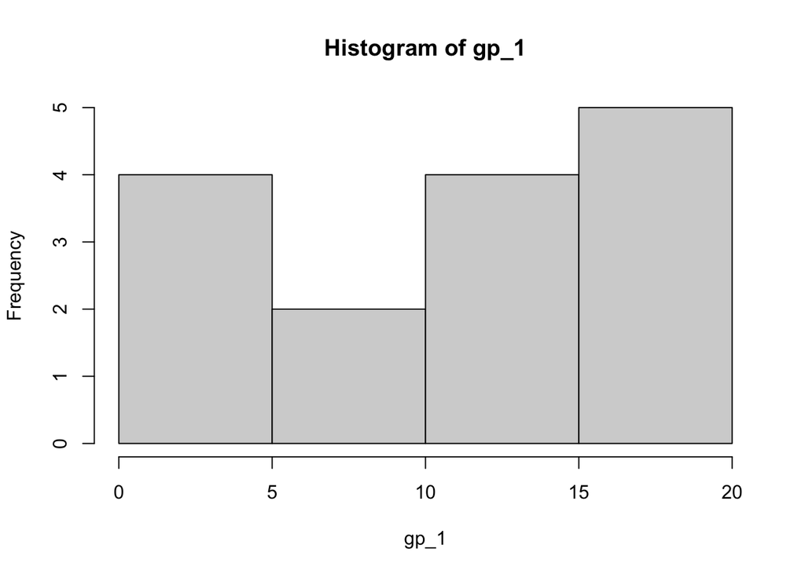

```r
set.seed(1414)
gp_1 <- sample.int(20, size = 15, replace = TRUE)

set.seed(1424)
gp_2 <- sample.int(30, size = 15, replace = TRUE)

#histograms
hist(gp_1)
```

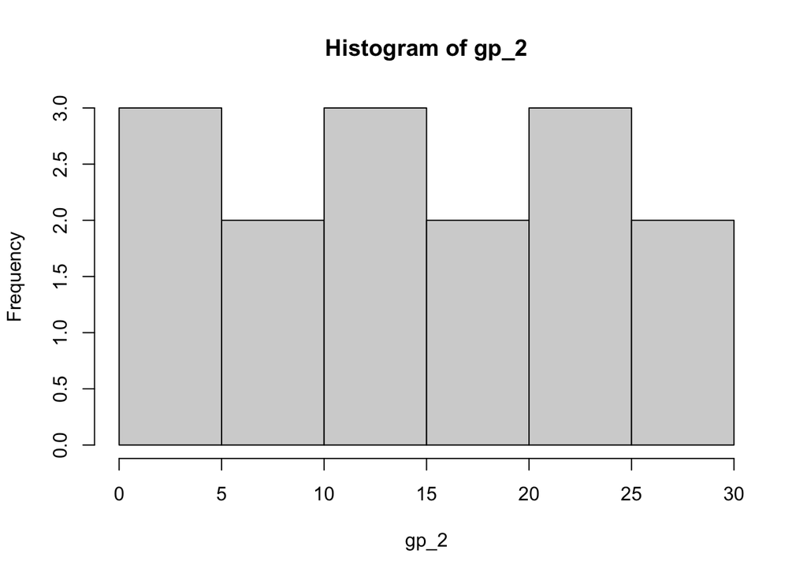

```r
hist(gp_2)
```

```r
##we’ll perform Mann-Whitney U to answer “Is there a significant difference in ranks (medians) between gp_1 and gp_2?” using the wilcox.test() function.
my_mwu <- wilcox.test(gp_1, gp_2)
## call to get output
my_mwu
```

```
##
##  Wilcoxon rank sum test with continuity correction
##
## data:  gp_1 and gp_2
## W = 86, p-value = 0.28
## alternative hypothesis: true location shift is not equal to 0
```

## Part 3: Simple linear regression

#We’ll exploring the relationship between two continuous variables, using the penguins dataset from the palmerpenguins package in R.

# A. exploratory scatterplot of penguing flipper length versus body mass

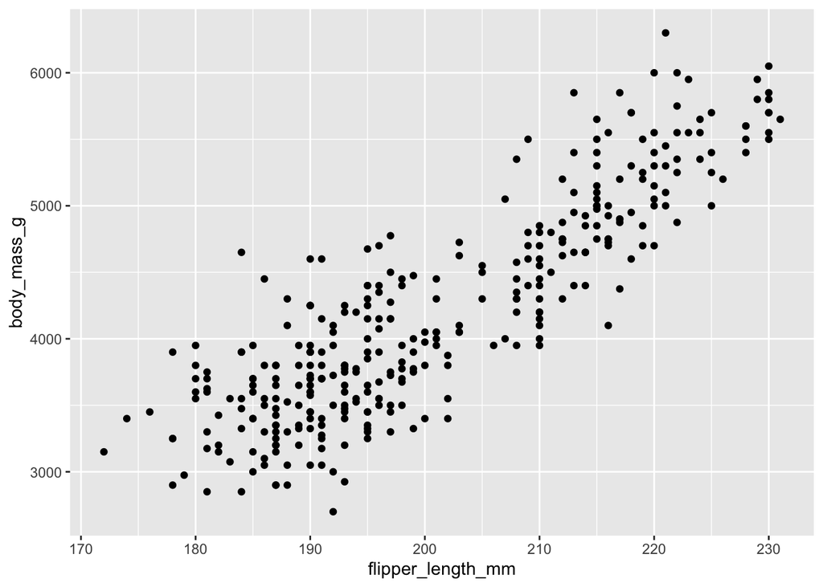

```r
ggplot(data = penguins, aes(x = flipper_length_mm, y = body_mass_g)) +
  geom_point()
```

## B. model it using lm().

```r
# Linear model, stored as penguin_lm:
penguin_lm <- lm(body_mass_g ~ flipper_length_mm, data = penguins)

# Return the complete overview:
summary(penguin_lm)
```

```
##
## Call:
## lm(formula = body_mass_g ~ flipper_length_mm, data = penguins)
##
## Residuals:
##      Min       1Q   Median       3Q      Max
## -1058.80  -259.27   -26.88   247.33  1288.69
##
## Coefficients:
##                    Estimate Std. Error t value Pr(>|t|)
## (Intercept)       -5780.831    305.815  -18.90   <2e-16 ***
## flipper_length_mm    49.686      1.518   32.72   <2e-16 ***
## ---
## Signif. codes:  0 '***' 0.001 '**' 0.01 '*' 0.05 '.' 0.1 ' ' 1
##
## Residual standard error: 394.3 on 340 degrees of freedom
##   (2 observations deleted due to missingness)
## Multiple R-squared:  0.759,  Adjusted R-squared:  0.7583
## F-statistic:  1071 on 1 and 340 DF,  p-value: < 2.2e-16
```

## C. Access model outputs

### We can access the coefficients for the model using:

##The slope is 49.69 (g / mm) ##The y-intercept is -5780.83 (g) ##The full equation is mass = 49.69*(flipper length) + (-5780.83) ##But trying to get all of the statistical information from the summary() function would be kind of a mess.

## We can use the broom::tidy() function to get the model outputs in nice data frame format:

```r
penguin_lm_tidy <- broom::tidy(penguin_lm)

# Get the intercept:
penguin_int <- penguin_lm_tidy$estimate[1]
penguin_int
```

```
## [1] -5780.831
```

```r
# Metrics at a glance:
penguin_lm_out <- broom::glance(penguin_lm)
penguin_lm_out
```

```
## # A tibble: 1 x 12
##   r.squared adj.r.squared sigma statistic   p.value    df logLik   AIC   BIC
##       <dbl>         <dbl> <dbl>     <dbl>     <dbl> <dbl>  <dbl> <dbl> <dbl>
## 1     0.759         0.758  394.     1071. 4.37e-107     1 -2528. 5063. 5074.
## # … with 3 more variables: deviance <dbl>, df.residual <int>, nobs <int>
```

## D. Explore model assumptions

## Recall that we have assumptions for linear regression we need to explore, some related to the residuals.

### -Linearly related variables (CHECK - already looked & thought hard)

### - Normally distributed residuals

### - Homoscedasticity (constant residuals variance)

### - iid residuals (no serial correlation) - more often a concern in time series data

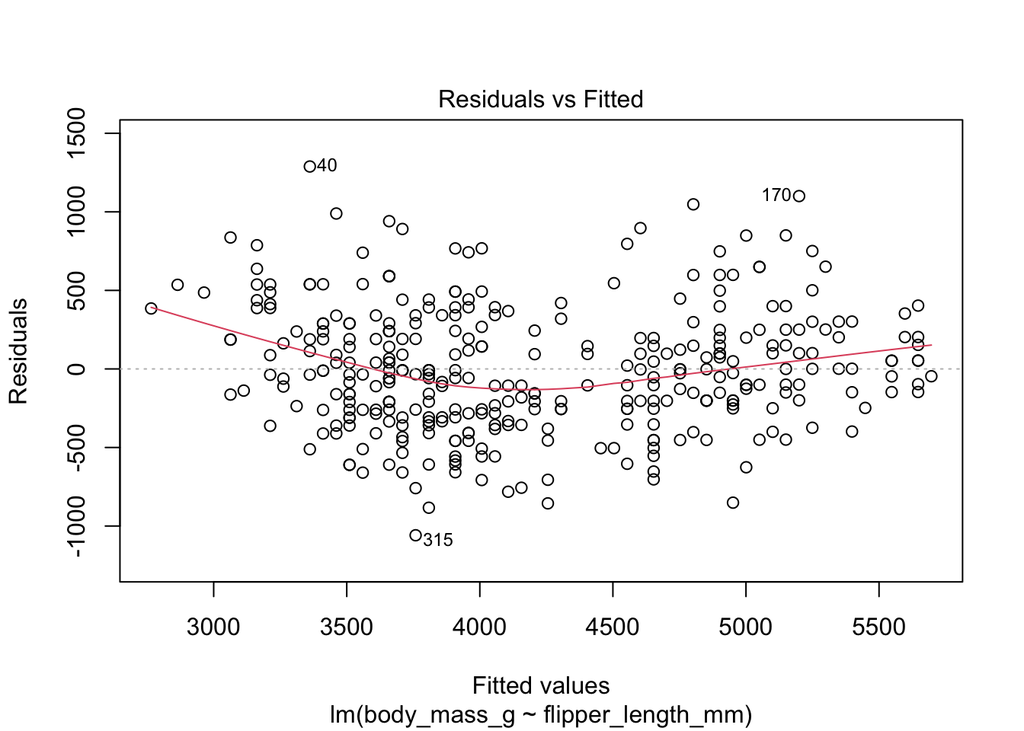

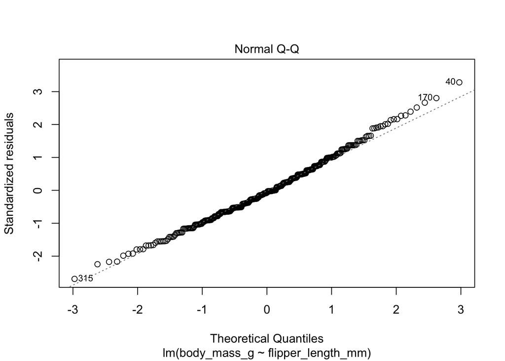

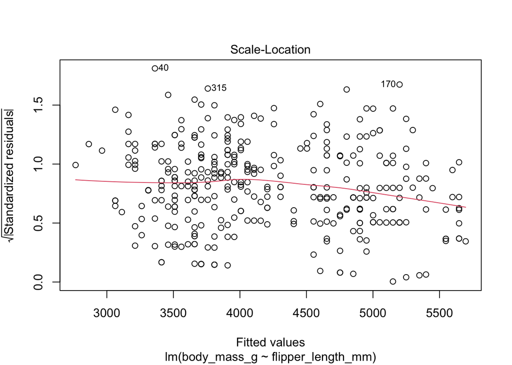

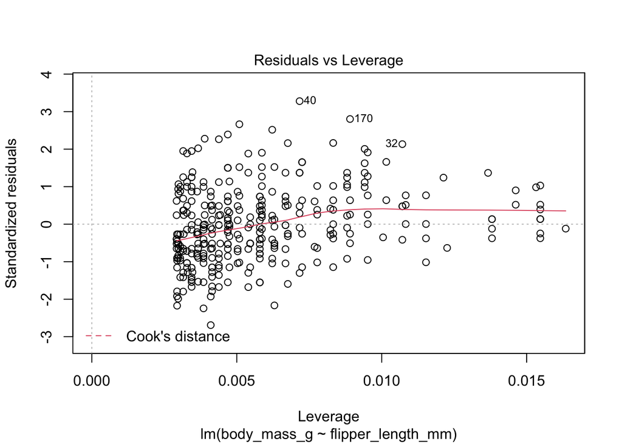

```r
plot(penguin_lm)
```

## E. Visualize the model

### Now that we’ve explore the assumptions and have decided that linear regression is a valid tool to describe the relationship between flipper length and body mass, let’s look at the model.

### - Use geom_smooth(method = “lm”) to add a linear model to an existing scatterplot

### - Use stat_cor() and/or stat_regline_equation() to add equation information directly to the plot panel, at an x- and y-position that you specify (and yes, you can mess with the digits & appearance here)